# act_report

## WeRateDogs Data Analysis Project (act_report)

Dogs are one of the most beloved pets in the world, and for good reason. These furry friends bring so much joy and love into our lives, and it’s no secret that they are man’s best friends. Have you ever wondered what kind of dogs are the most popular or most loved? Perhaps you're looking to get a dog, either as a first time owner or a once dog parent. Look no further, this article will give you interesting insights about these lovely creatures and leave you better informed based on public opinion. This article is an excerpt from my data analysis project WeRateDogs. The project analyses tweets from the popular Twitter account "@dog_rates" giving you insights on top rated dogs by public interest.

As you may already know, Dogs go through four distinct stages of life: doggo, puppo, pupper, and floofer. Doggos are full-grown adults known for their loyalty and obedience. Puppos are young adults full of energy and playfulness. Puppers are between 6 months and 1 year old, and known for their adorable appearance and cuddliness. Floofers have the fluffiest of coats and are known for their plush appearance. Each stage brings its own unique characteristics and cuteness to our lives.

### The most popular dogs

After analyzing the tweets of the @dog_rates account, the puppers are the most popular amongst many dog owners, credit to their beautiful appearance and cuddliness. To see how the other dog types place, see the chart below.

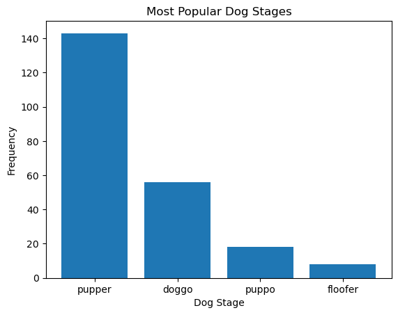

### The most loved dogs

Take a guess. Of the four stages of dog life which do you think people love the most? If you said doggos then cheers, you picked right. Of course people love obedience and loyalty, and doggos are most popular for this hence there is no surprise. Also, they are great for families, as they are playful and entertaining, making them perfect playmates for children. Closely after doggos are puppers. Puppers are loved for their adorable and playful personalities. They are still young and have a lot of energy, which makes them fun to be around. Their cute appearance, with soft fur and floppy ears, also makes them incredibly loveable.

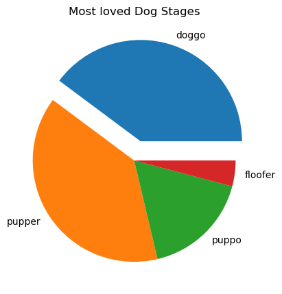

### Top 5 dog breeds

Take this one as a bonus. Don't thank me, let's send that appreciation to @dog_rates for their good work. Anyway, the top rated dog breeds are listed below, hopefully that can influence your choice of breed. Cheers!

- Golden retriever
- Labrador retriever
- Pembroke
- Chihuahua
- Samoyed